# • DOMAIN: Semiconductor manufacturing process

# • CONTEXT: A complex modern semiconductor manufacturing process is normally under constant surveillance via the monitoring of signals/variables collected from sensors and or process measurement points. However, not all of these signals are equally valuable in a specific monitoring system. The measured signals contain a combination of useful information, irrelevant information as well as noise. Engineers typically have a much larger number of signals than are actually required. If we consider each type of signal as a feature, then feature selection may be applied to identify the most relevant signals. The Process Engineers may then use these signals to determine key factors contributing to yield excursions downstream in the process. This will enable an increase in process throughput, decreased time to learning and reduce the per unit production costs. These signals can be used as features to predict the yield type. And by analysing and trying out different combinations of features, essential signals that are impacting the yield type can be identified.

# • DATA DESCRIPTION: sensor-data.csv : (1567, 592)

```
The data consists of 1567 datapoints each with 591 features.
The dataset presented in this case represents a selection of such features where each example represents a single
production entity with associated measured features and the labels represent a simple pass/fail yield for in house
line testing. Target column “ –1” corresponds to a pass and “1” corresponds to a fail and the data time stamp is
for that specific test point.
```

# • PROJECT OBJECTIVE: We will build a classifier to predict the Pass/Fail yield of a particular process entity and analyse whether all the features are required to build the model or not.

```python
# Import all the necessary libraries:

import numpy as np
import pandas as pd
import seaborn as sns
import matplotlib.pyplot as plt
%matplotlib inline
from matplotlib import cm

from sklearn.preprocessing import MinMaxScaler
from sklearn.preprocessing import LabelEncoder
from sklearn.preprocessing import StandardScaler

from sklearn.linear_model import LogisticRegression
from sklearn.naive_bayes import GaussianNB
from sklearn.neighbors import KNeighborsClassifier
from sklearn.svm import SVC

from sklearn.tree import DecisionTreeClassifier
from sklearn.tree import export_graphviz
from IPython.display import Image
from sklearn.tree import plot_tree
from sklearn.ensemble import RandomForestClassifier
from sklearn.ensemble import BaggingClassifier
from sklearn.ensemble import AdaBoostClassifier
from sklearn.ensemble import GradientBoostingClassifier
import xgboost as xgb
from xgboost import XGBClassifier

from sklearn.decomposition import PCA
from sklearn.cluster import KMeans

import sklearn.metrics as metrics
from sklearn.metrics import accuracy_score, confusion_matrix, precision_score, recall_score, f1_score, classification_report

from sklearn import model_selection
from sklearn.model_selection import LeaveOneOut
from sklearn.model_selection import StratifiedKFold
from sklearn.model_selection import RepeatedStratifiedKFold
from sklearn.model_selection import RandomizedSearchCV
from sklearn.model_selection import GridSearchCV
from sklearn.model_selection import train_test_split
from sklearn.model_selection import cross_val_score, learning_curve, validation_curve

from scipy import stats
from scipy.stats import zscore

from imblearn.over_sampling import SMOTE
from imblearn.over_sampling import RandomOverSampler

from sklearn.utils import resample

from sklearn.pipeline import Pipeline

from sklearn.linear_model import Lasso

from statsmodels.stats.outliers_influence import variance_inflation_factor

import warnings
warnings.filterwarnings("ignore")
```

# 1. Import and understand the data.

# A. Import ‘signal-data.csv’ as DataFrame.

```python
# Import signal-data.csv and save it into DF DataFrame

DF = pd.read_csv('signal-data.csv')

SIGNAL_DATA = DF.copy()
```

```python
DF.head()
```

|  | Time | 0 | 1 | 2 | 3 | 4 | 5 | 6 | 7 | 8 | ... | 581 | 582 | 583 | 584 | 585 | 586 | 587 | 588 | 589 | Pass/Fail |
| --- | --- | --- | --- | --- | --- | --- | --- | --- | --- | --- | --- | --- | --- | --- | --- | --- | --- | --- | --- | --- | --- |
| 0 | 2008-07-19 11:55:00 | 3030.93 | 2564.00 | 2187.7333 | 1411.1265 | 1.3602 | 100.0 | 97.6133 | 0.1242 | 1.5005 | ... | NaN | 0.5005 | 0.0118 | 0.0035 | 2.3630 | NaN | NaN | NaN | NaN | -1 |
| 1 | 2008-07-19 12:32:00 | 3095.78 | 2465.14 | 2230.4222 | 1463.6606 | 0.8294 | 100.0 | 102.3433 | 0.1247 | 1.4966 | ... | 208.2045 | 0.5019 | 0.0223 | 0.0055 | 4.4447 | 0.0096 | 0.0201 | 0.0060 | 208.2045 | -1 |
| 2 | 2008-07-19 13:17:00 | 2932.61 | 2559.94 | 2186.4111 | 1698.0172 | 1.5102 | 100.0 | 95.4878 | 0.1241 | 1.4436 | ... | 82.8602 | 0.4958 | 0.0157 | 0.0039 | 3.1745 | 0.0584 | 0.0484 | 0.0148 | 82.8602 | 1 |
| 3 | 2008-07-19 14:43:00 | 2988.72 | 2479.90 | 2199.0333 | 909.7926 | 1.3204 | 100.0 | 104.2367 | 0.1217 | 1.4882 | ... | 73.8432 | 0.4990 | 0.0103 | 0.0025 | 2.0544 | 0.0202 | 0.0149 | 0.0044 | 73.8432 | -1 |
| 4 | 2008-07-19 15:22:00 | 3032.24 | 2502.87 | 2233.3667 | 1326.5200 | 1.5334 | 100.0 | 100.3967 | 0.1235 | 1.5031 | ... | NaN | 0.4800 | 0.4766 | 0.1045 | 99.3032 | 0.0202 | 0.0149 | 0.0044 | 73.8432 | -1 |

5 rows × 592 columns

```python
DF.tail()
```

|  | Time | 0 | 1 | 2 | 3 | 4 | 5 | 6 | 7 | 8 | ... | 581 | 582 | 583 | 584 | 585 | 586 | 587 | 588 | 589 | Pass/Fail |
| --- | --- | --- | --- | --- | --- | --- | --- | --- | --- | --- | --- | --- | --- | --- | --- | --- | --- | --- | --- | --- | --- |
| 1562 | 2008-10-16 15:13:00 | 2899.41 | 2464.36 | 2179.7333 | 3085.3781 | 1.4843 | 100.0 | 82.2467 | 0.1248 | 1.3424 | ... | 203.1720 | 0.4988 | 0.0143 | 0.0039 | 2.8669 | 0.0068 | 0.0138 | 0.0047 | 203.1720 | -1 |
| 1563 | 2008-10-16 20:49:00 | 3052.31 | 2522.55 | 2198.5667 | 1124.6595 | 0.8763 | 100.0 | 98.4689 | 0.1205 | 1.4333 | ... | NaN | 0.4975 | 0.0131 | 0.0036 | 2.6238 | 0.0068 | 0.0138 | 0.0047 | 203.1720 | -1 |
| 1564 | 2008-10-17 05:26:00 | 2978.81 | 2379.78 | 2206.3000 | 1110.4967 | 0.8236 | 100.0 | 99.4122 | 0.1208 | NaN | ... | 43.5231 | 0.4987 | 0.0153 | 0.0041 | 3.0590 | 0.0197 | 0.0086 | 0.0025 | 43.5231 | -1 |
| 1565 | 2008-10-17 06:01:00 | 2894.92 | 2532.01 | 2177.0333 | 1183.7287 | 1.5726 | 100.0 | 98.7978 | 0.1213 | 1.4622 | ... | 93.4941 | 0.5004 | 0.0178 | 0.0038 | 3.5662 | 0.0262 | 0.0245 | 0.0075 | 93.4941 | -1 |
| 1566 | 2008-10-17 06:07:00 | 2944.92 | 2450.76 | 2195.4444 | 2914.1792 | 1.5978 | 100.0 | 85.1011 | 0.1235 | NaN | ... | 137.7844 | 0.4987 | 0.0181 | 0.0040 | 3.6275 | 0.0117 | 0.0162 | 0.0045 | 137.7844 | -1 |

5 rows × 592 columns

```python
print('EXPORTED DATA FRAME CONTAINS',DF.shape[0],'ROWS AND',DF.shape[1],'COLUMNS')
```

```
EXPORTED DATA FRAME CONTAINS 1567 ROWS AND 592 COLUMNS
```

```python
DF.columns
```

```
Index(['Time', '0', '1', '2', '3', '4', '5', '6', '7', '8',
       ...
       '581', '582', '583', '584', '585', '586', '587', '588', '589',
       'Pass/Fail'],
      dtype='object', length=592)
```

```python
print(DF.dtypes.unique())
```

```
[dtype('O') dtype('float64') dtype('int64')]
```

```python
DF.info()
```

```
<class 'pandas.core.frame.DataFrame'>
RangeIndex: 1567 entries, 0 to 1566
Columns: 592 entries, Time to Pass/Fail
dtypes: float64(590), int64(1), object(1)
memory usage: 7.1+ MB
```

```
* THE SIGNAL DATA FRAME CONTAINS 1567 ROWS AND 592 COLUMNS
* ONLY TIME COLUMN IS OF OBJECT TYPE AND PASS / FAIL IS OF INT TYPE
* REMAINING 590 COLUMNS ARE OF FLOATING DATA TYPE.
* SINCE THE COLUMN NAMES ARE HAVING NUMBERS, AS MENTIONED IN THE DESCRIPTION WE WILL APPEND THE NAME FEATURE
  TO ALL THOSE COLUMNS AND MAKE THEN READABLE.
```

# B. Print 5 point summary and share at least 2 observations.

```python
print(DF.describe().T)
```

```
            count         mean         std        min          25%        50%  \
0          1561.0  3014.452896   73.621787  2743.2400  2966.260000  3011.4900
1          1560.0  2495.850231   80.407705  2158.7500  2452.247500  2499.4050
2          1553.0  2200.547318   29.513152  2060.6600  2181.044400  2201.0667
3          1553.0  1396.376627  441.691640     0.0000  1081.875800  1285.2144
4          1553.0     4.197013   56.355540     0.6815     1.017700     1.3168
...           ...          ...         ...        ...          ...        ...
586        1566.0     0.021458    0.012358    -0.0169     0.013425     0.0205
587        1566.0     0.016475    0.008808     0.0032     0.010600     0.0148
588        1566.0     0.005283    0.002867     0.0010     0.003300     0.0046
589        1566.0    99.670066   93.891919     0.0000    44.368600    71.9005
Pass/Fail  1567.0    -0.867262    0.498010    -1.0000    -1.000000    -1.0000

                 75%        max
0          3056.6500  3356.3500
1          2538.8225  2846.4400
2          2218.0555  2315.2667
3          1591.2235  3715.0417
4             1.5257  1114.5366
...              ...        ...
586           0.0276     0.1028
587           0.0203     0.0799
588           0.0064     0.0286
589         114.7497   737.3048
Pass/Fail    -1.0000     1.0000

[591 rows x 8 columns]
```

```
* COUNTS OF VARIOUS FEATURES ARE DIFFER FROM EACH OTHER

* FROM THE ABOVE INFO, WE CAN SEE THAT THERE ARE DEFINITELY NULL VALUES PRESENT IN THE DATA.

* COLUMNS 72,73,85,109,110,111,112,157,158,220,244,245,246,247,292,293,345,346,358,382,383,384,385,492,
  516,517,518,519,578,579,580,581 HAS MORE MORE THAN 40% OF MISSING DATA AND SOME OF THEM EVEN HAVE MORE THAN
  50 OF THE DATA MISSING.

* COLUMN 546 TO 557, 562 TO 569 HAS MORE THAN 200 FIELDS OF MISSING DATA.

* SOME OF THE FEATURES SEEMS TO BE HAVING NEGATIVE VALUES AS WELL.

* THERE ARE SIGNIFICANT AMOUNT OF OUTLIERS AS SEEN BETWEEN THE 75% AND MAX VALUE PRESENT IN THE DATA.
```

# 2. Data cleansing:

# A. Write a for loop which will remove all the features with 20%+ Null values and impute rest with mean of the feature.

```python
COLUMNS = DF.columns

NULL_COLS = pd.DataFrame(columns = ['COLUMN_NAME','NULL_VALUES_COUNT'])

COLUMN_NAME = []
NULL_PER = []

for i in COLUMNS:
    PER = (DF[i].isnull().sum()/1567)*100
    if PER > 20:
        COLUMN_NAME.append(i)
        NULL_PER.append(PER)
        DF = DF.drop(columns = i)
    elif PER > 0 and PER < 20:
        DF[i] = DF[i].fillna(DF[i].mean())

NULL_COLS = pd.DataFrame(list(zip(COLUMN_NAME,NULL_PER)),columns = ['COLUMN_NAME','NULL_PER'])

print('BELOW ARE THE COLUMNS WITH NULL VALUES MORE THAN 20% AND DROPPED FROM THE DATA:\n\n', NULL_COLS)

print('\nAFTER DROPPING, DATA FRAME CONTAINS',DF.shape[0],'ROWS AND',DF.shape[1],'COLUMNS')
```

```
BELOW ARE THE COLUMNS WITH NULL VALUES MORE THAN 20% AND DROPPED FROM THE DATA:

    COLUMN_NAME   NULL_PER
0           72  50.670070
1           73  50.670070
2           85  85.577537
3          109  64.964901
4          110  64.964901
5          111  64.964901
6          112  45.628590
7          157  91.193363
8          158  91.193363
9          220  85.577537
10         244  64.964901
11         245  64.964901
```

[output cut: 22 more lines]

```
* WE COULD SEE THE ABOVE 32 COLUMNS HAVE MISSING VALUES PERCENTAGE OF MORE THAN 20%

* WE HAVE DROPPED ALL THESE 32 COLUMNS FROM THE DATA FRAME.

* NEW DATA FRAME CONTAINS 560 COLUMNS.
```

```python
COLUMNS = DF.columns

for i in COLUMNS:
    COUNT = DF[i].isnull().sum()

if COUNT == 0:
    print('THERE ARE NO NULL / MISSING VALUES PRESENT IN THE DATA')
else:
    print('THERE ARE NULL / MISSING VALUES STILL PRESENT IN THE DATA')
```

```
THERE ARE NO NULL / MISSING VALUES PRESENT IN THE DATA
```

# B. Identify and drop the features which are having same value for all the rows.

```python
COLUMNS = DF.columns

COLS_SAME_VALUE = pd.DataFrame(columns = ['COLUMN_NAME','UNIQUE_VALUE'])

COLUMN_NAME = []
UNIQUE_VALUE = []

for i in COLUMNS:
    COUNT = DF[i].nunique()
    VAL = DF[i].unique()
    if COUNT == 1:
        COLUMN_NAME.append(i)
        UNIQUE_VALUE.append(VAL[0])
        DF = DF.drop(columns = i)

COLS_SAME_VALUE = pd.DataFrame(list(zip(COLUMN_NAME,UNIQUE_VALUE)),columns = ['COLUMN_NAME','UNIQUE_VALUE'])

print('BELOW ARE THE',len(COLUMN_NAME),'COLUMNS WITH SAME VALUES FOR ALL THE ROWS:\n\n', COLS_SAME_VALUE)

print('\nAFTER DROPPING, DATA FRAME CONTAINS',DF.shape[0],'ROWS AND',DF.shape[1],'COLUMNS')
```

```
BELOW ARE THE 116 COLUMNS WITH SAME VALUES FOR ALL THE ROWS:

     COLUMN_NAME  UNIQUE_VALUE
0             5         100.0
1            13           0.0
2            42          70.0
3            49           1.0
4            52           0.0
..          ...           ...
111         534           0.0
112         535           0.0
113         536           0.0
114         537           0.0
115         538           0.0

[116 rows x 2 columns]

AFTER DROPPING, DATA FRAME CONTAINS 1567 ROWS AND 444 COLUMNS
```

```python
print('\nAFTER DROPPING, DATA FRAME CONTAINS',DF.shape[0],'ROWS AND',DF.shape[1],'COLUMNS')
```

```
AFTER DROPPING, DATA FRAME CONTAINS 1567 ROWS AND 444 COLUMNS
```

```
* IN THE EXPORTED SIGNAL DATA, WE CAN SEE THAT THERE ARE 116 FEATURES WHICH HAVE SAME VALUE ACROSS ALL ROWS.

* WE USED FOR LOOP TO FIND SUCH COLUMNS WITH ONLY ONE VALUE FOR ALL ROWS AND DROPPED THEM USING FOR LOOP.

* AFTER DROPPING THESE COLUMNS, THERE ARE TOTAL OF 444 FEATURES PRESENT IN THE DATA SET.
```

# C. Drop other features if required using relevant functional knowledge. Clearly justify the same.

```python
FEATURES = DF.drop(columns = ['Time','Pass/Fail'])
RESULTS = DF['Pass/Fail']
lasso = Lasso(alpha=0.01)
lasso.fit(FEATURES,RESULTS)
#print ("Lasso model:", (lasso.coef_))

UNIMP_FEATURES = FEATURES.columns[(lasso.coef_ != 0).ravel().tolist()] # Unimportant features where lasso_coef_ is zero

DF_NEW = DF.drop(columns = UNIMP_FEATURES.to_list())
```

```python
print('\nAFTER DROPPING, DATA FRAME CONTAINS',DF_NEW.shape[0],'ROWS AND',DF_NEW.shape[1],'COLUMNS')
```

```
AFTER DROPPING, DATA FRAME CONTAINS 1567 ROWS AND 296 COLUMNS
```

[output not shown]

```python
DF_NEW = DF_NEW.drop(columns = 'Time')
```

```
* WE CAN DIS-INTEGRATE THE TIME COLUMN TO YEAR, MONTH, DAY AND TIME FIELDS TO SEE WHETHER SIGNALS PROCESSED
  ON PARTICULAR MONTH / DAY / TIME PERTAINS TO FAIL OR PASS.

* I AM DROPPING THE TIME COLUMN FROM THE DATA CONSIDERING THAT THE SIGNAL PREDICTION FOR PASS/FAIL IS NOT
  FULLY DEPENDENT ON THE TIME.
```

```python
CORR_MTX = DF_NEW.corr()

ABOVE_ONES_CORR = CORR_MTX.where(np.triu(np.ones(CORR_MTX.shape),k=1).astype(np.bool))

ABOVE_ONES_CORR
```

|  | 4 | 7 | 8 | 9 | 10 | 11 | 12 | 16 | 17 | 18 | ... | 573 | 575 | 582 | 583 | 584 | 585 | 586 | 587 | 588 | Pass/Fail |
| --- | --- | --- | --- | --- | --- | --- | --- | --- | --- | --- | --- | --- | --- | --- | --- | --- | --- | --- | --- | --- | --- |
| 4 | NaN | -0.347734 | -0.025946 | 0.054206 | -0.006470 | -0.000985 | -0.002707 | -0.001763 | 0.000284 | -0.001610 | ... | -0.016533 | -0.017884 | 0.045081 | -0.001300 | -0.001597 | -0.001616 | -0.043929 | -0.031005 | -0.026100 | -0.013756 |
| 7 | NaN | NaN | 0.020133 | -0.092075 | -0.004336 | -0.009653 | -0.001811 | 0.013214 | -0.000291 | -0.013804 | ... | 0.026621 | 0.032249 | -0.029916 | 0.010276 | 0.008676 | 0.010337 | 0.058113 | -0.021426 | -0.020893 | 0.012991 |
| 8 | NaN | NaN | NaN | -0.152133 | 0.058386 | -0.065065 | 0.005457 | 0.039571 | -0.014963 | -0.027687 | ... | 0.017232 | 0.017209 | -0.027611 | 0.017390 | 0.019951 | 0.017925 | 0.010433 | 0.022845 | 0.026250 | 0.028016 |
| 9 | NaN | NaN | NaN | NaN | -0.064065 | -0.008692 | -0.065125 | -0.027492 | -0.015672 | -0.051984 | ... | 0.034474 | 0.036089 | 0.046209 | -0.036036 | -0.032583 | -0.036109 | 0.033738 | 0.059301 | 0.060758 | -0.031191 |
| 10 | NaN | NaN | NaN | NaN | NaN | -0.021358 | -0.052534 | -0.062439 | -0.032645 | -0.008480 | ... | 0.021158 | 0.023715 | -0.073704 | 0.039060 | 0.039115 | 0.039447 | 0.000327 | 0.046965 | 0.046048 | 0.033639 |
| ... | ... | ... | ... | ... | ... | ... | ... | ... | ... | ... | ... | ... | ... | ... | ... | ... | ... | ... | ... | ... | ... |
| 585 | NaN | NaN | NaN | NaN | NaN | NaN | NaN | NaN | NaN | NaN | ... | NaN | NaN | NaN | NaN | NaN | NaN | 0.002743 | -0.002930 | -0.002530 | 0.005034 |
| 586 | NaN | NaN | NaN | NaN | NaN | NaN | NaN | NaN | NaN | NaN | ... | NaN | NaN | NaN | NaN | NaN | NaN | NaN | 0.167913 | 0.164238 | 0.004156 |
| 587 | NaN | NaN | NaN | NaN | NaN | NaN | NaN | NaN | NaN | NaN | ... | NaN | NaN | NaN | NaN | NaN | NaN | NaN | NaN | 0.974276 | 0.035391 |
| 588 | NaN | NaN | NaN | NaN | NaN | NaN | NaN | NaN | NaN | NaN | ... | NaN | NaN | NaN | NaN | NaN | NaN | NaN | NaN | NaN | 0.031167 |
| Pass/Fail | NaN | NaN | NaN | NaN | NaN | NaN | NaN | NaN | NaN | NaN | ... | NaN | NaN | NaN | NaN | NaN | NaN | NaN | NaN | NaN | NaN |

295 rows × 295 columns

# D. Check for multi-collinearity in the data and take necessary action.

[output not shown]

```python
# WE ARE USING VARIANCE INFLATION FACTOR TO DEAL WITH COLLINEARITY
# ANY COLUMN HAVING A VIF VALUE GREATER THAN 5 REPRESENTS THEY ARE HIGHLY COLLINEAR
# WE WILL CALCULATE VIF VALUE FOR ALL THE COLUMNS FIRST
# BUT WE WILL NOT DROP ALL THE COLUMNS THAT HAVE VALUE HIGHER THAN 5
# WE WILL DROP COLUMNS THAT HAVE VERY HIGH VIF VALUE FIRST AND THEN CALCULATE VIF AGAIN AND DROP OTHER COLUMNS

def DEAL_WITH_COLLINEARITY(DF_NEW):

    MULTI_COLLINEAR = pd.DataFrame()
    MULTI_FEATURES = DF_NEW.drop(columns = ['Pass/Fail'])
    MULTI_COLLINEAR["COLUMN"] = MULTI_FEATURES.columns
    MULTI_COLLINEAR["VIF_VALUE"] = [variance_inflation_factor(MULTI_FEATURES.values, i)
                          for i in range(len(MULTI_FEATURES.columns))]
    return MULTI_COLLINEAR
```

```python
MULTI_COLLINEAR = DEAL_WITH_COLLINEARITY(DF_NEW)
```

```python
COLS_TO_DROP = MULTI_COLLINEAR[MULTI_COLLINEAR['VIF_VALUE'] > 10000]

DF_NEW = DF_NEW.drop(columns = COLS_TO_DROP['COLUMN'])

print('\nAFTER DROPPING, DATA FRAME CONTAINS',DF_NEW.shape[0],'ROWS AND',DF_NEW.shape[1],'COLUMNS')
```

```
AFTER DROPPING, DATA FRAME CONTAINS 1567 ROWS AND 215 COLUMNS
```

```python
# RERUN THE FUNCTION AGAIN TO CALCULATE THE VIF VALUE FOR THE DATA

MULTI_COLLINEAR = DEAL_WITH_COLLINEARITY(DF_NEW)
```

```python
COLS_TO_DROP = MULTI_COLLINEAR[MULTI_COLLINEAR['VIF_VALUE'] > 2000]

DF_NEW = DF_NEW.drop(columns = COLS_TO_DROP['COLUMN'])

print('\nAFTER DROPPING, DATA FRAME CONTAINS',DF_NEW.shape[0],'ROWS AND',DF_NEW.shape[1],'COLUMNS')
```

```
AFTER DROPPING, DATA FRAME CONTAINS 1567 ROWS AND 201 COLUMNS
```

```python
# RERUN THE FUNCTION AGAIN TO CALCULATE THE VIF VALUE FOR THE DATA

MULTI_COLLINEAR = DEAL_WITH_COLLINEARITY(DF_NEW)
```

```python
COLS_TO_DROP = MULTI_COLLINEAR[MULTI_COLLINEAR['VIF_VALUE'] > 1000]

DF_NEW = DF_NEW.drop(columns = COLS_TO_DROP['COLUMN'])

print('\nAFTER DROPPING, DATA FRAME CONTAINS',DF_NEW.shape[0],'ROWS AND',DF_NEW.shape[1],'COLUMNS')
```

```
AFTER DROPPING, DATA FRAME CONTAINS 1567 ROWS AND 191 COLUMNS
```

```python
# RERUN THE FUNCTION AGAIN TO CALCULATE THE VIF VALUE FOR THE DATA

MULTI_COLLINEAR = DEAL_WITH_COLLINEARITY(DF_NEW)
```

```python
COLS_TO_DROP = MULTI_COLLINEAR[MULTI_COLLINEAR['VIF_VALUE'] > 500]

DF_NEW = DF_NEW.drop(columns = COLS_TO_DROP['COLUMN'])

print('\nAFTER DROPPING, DATA FRAME CONTAINS',DF_NEW.shape[0],'ROWS AND',DF_NEW.shape[1],'COLUMNS')
```

```
AFTER DROPPING, DATA FRAME CONTAINS 1567 ROWS AND 188 COLUMNS
```

```
* WE HAVE DROPPED THE COLUMNS THAT HAVE HIGH VIF VALUE AND DEALT WITH MULTI COLLINEARITY

* WE CAN STILL DROP COLUMNS THAT HAVE HIGH VALUE, BUT TO AVOID FURTHER DATA SHRINKAGE, WE ARE STOPPING AT
  THIS POINT AND PROCEED FURTHER.
```

# E. Make all relevant modifications on the data using both functional/logical reasoning/assumptions.

[output not shown]

# 3. Data analysis & visualisation:

# A. Perform a detailed univariate Analysis with appropriate detailed comments after each analysis. [

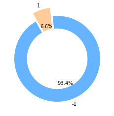

```python
my_labels = DF_NEW['Pass/Fail'].unique()

colors = ['#66b3ff','#ffcc99']


my_explode = [0,0.2]

plt.pie(DF_NEW['Pass/Fail'].value_counts(sort = False),startangle=120,autopct='%1.1f%%',
        labels = my_labels,colors = colors,explode = my_explode)

CIRCLE = plt.Circle( (0,0), 0.7, color='white')
PLOT = plt.gcf()
PLOT.gca().add_artist(CIRCLE)

plt.show()
```

```
* WE CAN SEE IN THE GIVEN DATA, MOST OF THE OUTCOME PERTAINS TO -1 OR PASS WITH 93.4%

* ONLY 6.6% OF THE SIGNALS ARE FAILED.

* IN OUR MODEL BUILDING THIS WILL IMPACT THE OUT COME HEAVILY TOWARDS THE PASS CATEGORY.
```

```
* WE WILL PLOT SOME SIGNALS FEATURES AND PLOT THEM
```

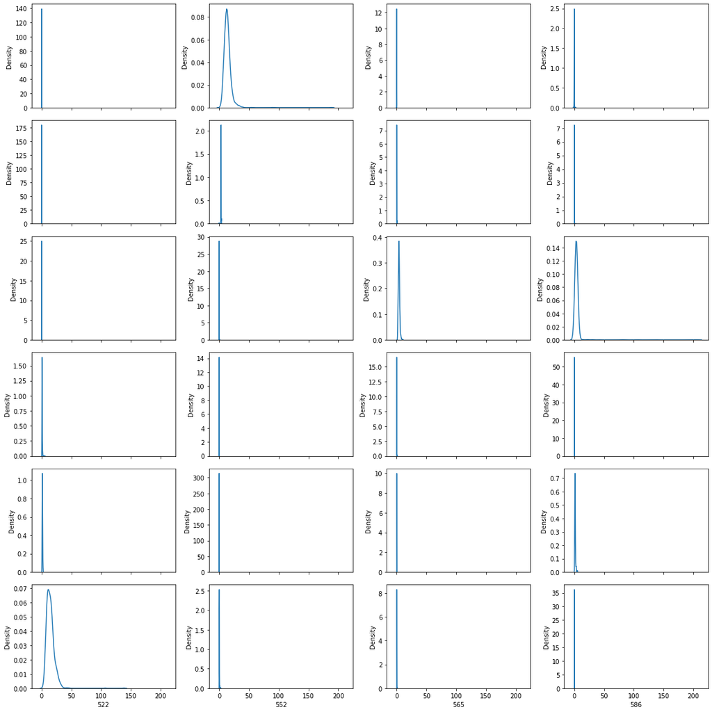

```python
# RANDOMLY PLOT THE FEATURES AND SEE THE UNIVARIATE ANALYSIS

fig, ax = plt.subplots(6,4 , sharex=True, figsize=(16,16))
x=0
y=0

COLS = []

X = np.arange(0,189,8)

for i in X:
    COLS.append(DF_NEW.columns[i])

for i in COLS:
    sns.kdeplot(DF_NEW[i],ax = ax[x, y])
    y = y+1
    if y == 4:
        x=x+1
        y=0

fig.tight_layout()
plt.show()
```

```
* WE HAVE RANDOMLY PLOTTED KDE PLOT FOR 24 FEATURES AND BELOW ARE THE OBSERVATIONS:

* MOST OF THE FEATURES ARE HAVING VALUE VERY CLOSE TO EACH OTHER.

* SOME OF THE FEATURES ARE SKEWED TO THE RIGHT AND REPRESENTS RIGHT SKEWNESS.

* WE WILL PROCEED WITH THE BI-VARIATE ANALYSIS OF THE DATA
```

# B. Perform bivariate and multivariate analysis with appropriate detailed comments after each analysis.

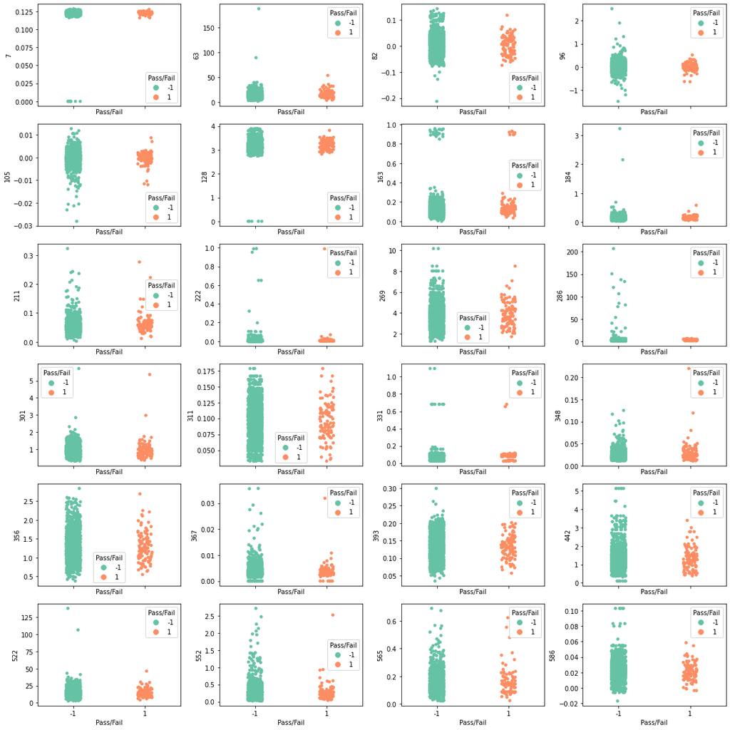

```python
# RANDOMLY PLOT THE FEATURES AND SEE THE BIVARIATE ANALYSIS

fig, ax = plt.subplots(6,4 , sharex=True, figsize=(16,16))
x=0
y=0

COLS = []

X = np.arange(0,189,8)

for i in X:
    COLS.append(DF_NEW.columns[i])

for i in COLS:
    sns.stripplot(y = DF_NEW[i], x = DF_NEW['Pass/Fail'],ax = ax[x, y],
                    palette="Set2", hue = DF_NEW['Pass/Fail'])
    y = y+1
    if y == 4:
        x=x+1
        y=0

fig.tight_layout()
plt.show()
```

```
* WE HAVE PLOTTED THE RANDOM FEATURES AGAINST THE TARGET COLUMN PASS/FAIL

* WE USED STRIP PLOT TO PLOT THESE FEATURES.

* WE COULD SEE THE MOST OF THE POINTS TENDS TO THE SIGNAL OUTPUT PASS
```

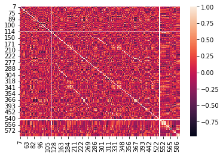

```python
sns.heatmap(DF_NEW[0:15].corr())

plt.show()
```

# 4. Data pre-processing:

# A. Segregate predictors vs target attributes.

```
* PREDICTORS: THESE ARE THE VARIABLES THAT ARE REQUIRED TO PREDICT THE TARGET VARIABLE.
              WE NEED A MINIMUM OF 1 PREDICTOR TO PREDICT THE TARGET VARIABLE.

* TARGET ATTRIBUTES: THESE ARE THE VARIABLE THAT ARE PREDICTED BY USING PREDICTORS.

IN OUR DATA FRAME, AFTER REFINING, WE CAN SAY THAT PASS/FAIL IS THE TARGET VARIABLE AND ALL OTHERS ARE
PREDICTORS.
```

```python
# PREDICTORS = ALL THE FEATURES "X" EXCEPT TARGET ATTRIBUTE THAT HELPS IN PREDICTING THE TARGET VARIABLE
# TARGET = ATTRIBUTE "Y" THAT NEEDS TO BE PREDICTED BASED ON TARGET VARIABLE USING THE SUITABLE MACHINE LEARNING MODEL

X = DF_NEW.drop(columns = 'Pass/Fail')

Y = DF_NEW['Pass/Fail']
```

# B. Check for target balancing and fix it if found imbalanced.

```python
print('BELOW ARE THE COUNTS OF TARGET VARIABLE PASS/FAIL:\n',Y.value_counts())
```

```
BELOW ARE THE COUNTS OF TARGET VARIABLE PASS/FAIL:
 -1    1463
 1     104
Name: Pass/Fail, dtype: int64
```

```
* -1 REPRESENTS THAT THE SIGNAL IS PASS AND 1 REPRESENTS THE SIGNAL IS FAIL.

* FROM THE ABOVE OUTPUT, WE CAN SEE THAT MORE SIGNALS ARE TENDING TOWARDS PASS CLASS (-1).

* MORE THAN 93% OF THE TARGET VARIABLE IS -1 (PASS) AND LESS THAN 7% IS 1 (FAIL).

* THERE IS A HUGE IMBALANCE IN THE TARGET VARIABLE WHERE ONE CLASS OF OUTPUT IS DOMINATING OTHER.

* WHEN WE BUILD A MODEL USING THIS DATA AS IS, MODEL INCLINES MORE TOWARDS -1 AS IT HAS MORE RECORDS.

* WE NEED TO BALANCE THE DATA SO THAT MODEL CAN LEARN AND CLASSIFY THE RECORDS TO EACH CLASS PROPERLY.

* WE WILL BALANCE THE DATA USING SMOTE OR RANDOM SAMPLING METHOD.
```

```python
# X_RS, Y_RS - RESAMPLED ATTRIBUTES USING SMOTE METHOD.

X_RS, Y_RS = SMOTE(random_state=1).fit_sample(X, Y.values.ravel())

print(X_RS.shape)
print('\n',Y_RS.shape)
print('\n\nBELOW ARE THE COUNTS OF TARGET VARIABLE PASS/FAIL:\n',np.unique(Y_RS,return_counts=True))
```

```
(2926, 187)

 (2926,)


BELOW ARE THE COUNTS OF TARGET VARIABLE PASS/FAIL:
 (array([-1,  1], dtype=int64), array([1463, 1463], dtype=int64))
```

```
* WE HAVE DONE OVER SAMPLING USING SMOTE METHOD AND NOW WE HAVE TOTAL OF 2926 ROWS

* OUT OF THE 2926 ROWS, WE CAN SEE THAT BOTH PASS AND FAIL CLASS CONTAINS 1463 RECORDS EACH.
```

# C. Perform train-test split and standardise the data or vice versa if required.

```python
# STANDARDISE THE DATA BEFORE SPLITTING INTO TRAIN AND TEST USING STANDARD SCALER METHOD

SC = StandardScaler()

X_RS_SCALER = SC.fit(X_RS)
```

```python
# SPLIT THE DATA INTO TRAIN, VALIDATION AND TEST

# X_TRAIN, Y_TRAIN - TRAINING DATA USED TO TRAIN THE MODEL
# X_TEST, Y_TEST - TESTING DATA TO EVALUATE THE MODEL AFTER TRAINING
# X_VAL, Y_VAL - DATA SET USED FOR VALUATION OF THE MODEL BEFORE EVALUATING AGAINST THE TESTING DATA

X_TRAIN, X_TEST, Y_TRAIN, Y_TEST = train_test_split(X_RS, Y_RS, test_size = .20, random_state=0)
X_TRAIN, X_VAL, Y_TRAIN, Y_VAL = train_test_split(X_TRAIN, Y_TRAIN, test_size=0.25, random_state=1)
```

[output not shown]

# D. Check if the train and test data have similar statistical characteristics when compared with original data.

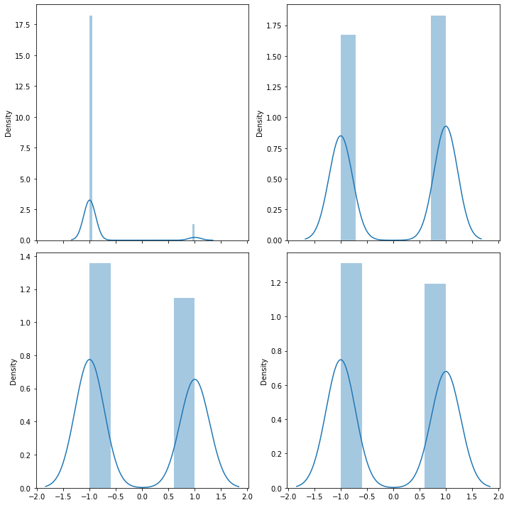

```python
fig, ax = plt.subplots(2,2 , sharex=True, figsize=(10,10))

sns.distplot(Y,ax = ax[0,0])
sns.distplot(Y_TRAIN,ax = ax[0,1])
sns.distplot(Y_VAL,ax = ax[1,0])
sns.distplot(Y_TEST,ax = ax[1,1])

fig.tight_layout()
plt.show()
```

```
* WE HAVE DRAWN THE DISTRIBUTION FOR THE ORIGINAL TARGET VARIABLE AND TARGET VARIABLE IN THE
  TRAINING, TEST AND VALIDATION DATA

* IN THE ORIGINAL DISTRIBUTION WE CAN SEE THAT PASS CLASS OF TARGET VARIABLE HAS HUGE BELL SHAPED BUT AFTER
  SAMPLING WE CAN SEE THAT THERE IS HUGE CHANGE IN THE DISTRIBUTION OF FAIL CLASS.

* AS VISIBLE ON THE ORIGINAL DATA, WE CAN SEE THAT ALL THE TRAINING, VALIDATION, TEST DATA SETS ALSO HAS 2 BUMPS
```

# 5. Model training, testing and tuning:

# A. Use any Supervised Learning technique to train a model.

```python
# I HAVE SELECTED ADA BOOST TO BUILD THE MACHINE LEARNING MODEL

RESULTS = pd.DataFrame()
NAME = "ADA BOOST CLASSIFIER"
MODEL_EVAL = AdaBoostClassifier()
MODEL_EVAL.fit(X_TRAIN, Y_TRAIN)
Y_PRED = MODEL_EVAL.predict(X_VAL)
ACCURACY = accuracy_score(Y_VAL, Y_PRED)
PRECISION = precision_score(Y_VAL, Y_PRED)
RECALL = recall_score(Y_VAL, Y_PRED)
F1_SCORE = f1_score(Y_VAL, Y_PRED)
RESULTS = RESULTS.append(pd.Series([NAME,ACCURACY,PRECISION,RECALL,F1_SCORE]),ignore_index=True)
RESULTS.columns = ['MODEL_NAME','ACCURACY','PRECISION','RECALL','F1-SCORE']
print('\nRESULTS USING ADA BOOST MACHINE LEARNING ALGORITHMS:\n')
print('*******************************************************************\n',RESULTS)
```

```
RESULTS USING ADA BOOST MACHINE LEARNING ALGORITHMS:

              MODEL_NAME  ACCURACY  PRECISION    RECALL  F1-SCORE
0  ADA BOOST CLASSIFIER  0.899145   0.859107  0.932836  0.894454
```

```
              precision    recall  f1-score   support

          -1       0.94      0.87      0.90       317
           1       0.86      0.93      0.89       268

    accuracy                           0.90       585
   macro avg       0.90      0.90      0.90       585
weighted avg       0.90      0.90      0.90       585
```

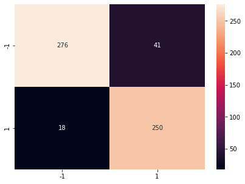

```python
print(classification_report(Y_VAL,Y_PRED),'\n\n\n')

CM = metrics.confusion_matrix(Y_VAL, Y_PRED,labels=[-1, 1])

CM_DF = pd.DataFrame(CM, index = [i for i in ["-1","1"]],
                  columns = [i for i in ["-1","1"]])

plt.figure(figsize = (7,5))

sns.heatmap(CM_DF, annot=True ,fmt='g')
```

```
* WE USED ADA BOOST CLASSIFIER FOR BUILDING THE MACHINE LEARNING MODEL.

* WE GOT NEARLY 90% OF ACCURACY ON THE MODEL

* THERE 41 PASS SIGNALS THAT ARE CLASSIFIED AS FAIL AND 18 FAIL SIGNALS AS PASS.

* WE WILL TUNE THE PARAMETERS AND SEE THERE IS IMPROVEMENT IN THE MODEL PERFORMANCE
```

# # B. Use cross validation techniques.

```python
#KFOLD CROSS VALIDATION TECHNIQUE

MODEL_RESULTS = pd.DataFrame()

MODEL_NAME = "KFOLD CV ON TRAINING DATA"
scoring = 'accuracy'
KFOLD = model_selection.KFold(n_splits=10, random_state=7,shuffle=True)
CV_RESULTS = model_selection.cross_val_score(AdaBoostClassifier(),  X_TRAIN,Y_TRAIN, cv = KFOLD, scoring=scoring)
MEAN = CV_RESULTS.mean()
STD = CV_RESULTS.std()
MODEL_RESULTS = MODEL_RESULTS.append(pd.Series([MODEL_NAME, MEAN, STD]),ignore_index=True)

MODEL_NAME = "KFOLD CV ON VALIDATION DATA"
scoring = 'accuracy'
KFOLD = model_selection.KFold(n_splits=10, random_state=7,shuffle=True)
CV_RESULTS = model_selection.cross_val_score(AdaBoostClassifier(),  X_VAL,Y_VAL, cv = KFOLD, scoring=scoring)
MEAN = CV_RESULTS.mean()
STD = CV_RESULTS.std()
MODEL_RESULTS = MODEL_RESULTS.append(pd.Series([MODEL_NAME, MEAN, STD]),ignore_index=True)
```

```python
#LEAVE ONE OUT CROSS VALIDATION TECHNIQUE

MODEL_NAME = "LEAVE ONE OUT CV ON TRAINING DATA"
scoring = 'accuracy'
LOOCV = model_selection.LeaveOneOut()
CV_RESULTS = model_selection.cross_val_score(AdaBoostClassifier(),  X_TRAIN,Y_TRAIN, cv = LOOCV,
                                             scoring=scoring, n_jobs = -1)
MEAN = CV_RESULTS.mean()
STD = CV_RESULTS.std()
MODEL_RESULTS = MODEL_RESULTS.append(pd.Series([MODEL_NAME, MEAN, STD]),ignore_index=True)

MODEL_NAME = "LEAVE ONE OUT CV ON VALIDATION DATA"
scoring = 'accuracy'
LOOCV = model_selection.LeaveOneOut()
CV_RESULTS = model_selection.cross_val_score(AdaBoostClassifier(),  X_VAL,Y_VAL, cv = LOOCV,
                                             scoring=scoring, n_jobs = -1)
MEAN = CV_RESULTS.mean()
STD = CV_RESULTS.std()
MODEL_RESULTS = MODEL_RESULTS.append(pd.Series([MODEL_NAME, MEAN, STD]),ignore_index=True)
```

```python
#STRATIFIED KFOLD CROSS VALIDATION TECHNIQUE

MODEL_NAME = "STRATIFIED KFOLD CV ON TRAINING DATA"
scoring = 'accuracy'
SKFCV = StratifiedKFold(n_splits = 15, shuffle=True, random_state = 65)
CV_RESULTS = model_selection.cross_val_score(AdaBoostClassifier(),  X_TRAIN,Y_TRAIN, cv = SKFCV, scoring=scoring)
MEAN = CV_RESULTS.mean()
STD = CV_RESULTS.std()
MODEL_RESULTS = MODEL_RESULTS.append(pd.Series([MODEL_NAME, MEAN, STD]),ignore_index=True)

MODEL_NAME = "STRATIFIED KFOLD CV ON VALIDATION DATA"
scoring = 'accuracy'
STRATIFIED_KFOLD = StratifiedKFold(n_splits = 15, shuffle=True, random_state = 65)
CV_RESULTS = model_selection.cross_val_score(AdaBoostClassifier(),  X_VAL,Y_VAL, cv = SKFCV, scoring=scoring)
MEAN = CV_RESULTS.mean()
STD = CV_RESULTS.std()
MODEL_RESULTS = MODEL_RESULTS.append(pd.Series([MODEL_NAME, MEAN, STD]),ignore_index=True)
```

```python
#USING BOOTSTRAPPING METHOD:

MODEL_NAME = "BOOTSTRAPPING CV ON MODEL PERFORMANCE"

ABC = AdaBoostClassifier()
ACCURACY = []

for i in range(0,11,1):
    X_BS, Y_BS = resample(X_TRAIN,Y_TRAIN)
    ABC.fit(X_BS,Y_BS)
    Y_PRED = ABC.predict(X_VAL)
    ACC = accuracy_score(Y_PRED,Y_VAL)
    ACCURACY.append(ACC)

MEAN = np.mean(ACCURACY)
STD = np.std(ACCURACY)

MODEL_RESULTS = MODEL_RESULTS.append(pd.Series([MODEL_NAME, MEAN, STD]),ignore_index=True)
```

```python
MODEL_RESULTS.columns = ['CROSS VALIDATION METHOD', 'MEAN ACCURACY', 'STD DEV OF ACCURACY']
```

```python
print(MODEL_RESULTS)
```

```
                  CROSS VALIDATION METHOD  MEAN ACCURACY  STD DEV OF ACCURACY
0               KFOLD CV ON TRAINING DATA       0.892851             0.019657
1             KFOLD CV ON VALIDATION DATA       0.854822             0.031235
2       LEAVE ONE OUT CV ON TRAINING DATA       0.891738             0.310711
3     LEAVE ONE OUT CV ON VALIDATION DATA       0.873504             0.332407
4    STRATIFIED KFOLD CV ON TRAINING DATA       0.895157             0.028169
5  STRATIFIED KFOLD CV ON VALIDATION DATA       0.851282             0.054754
6   BOOTSTRAPPING CV ON MODEL PERFORMANCE       0.875991             0.009569
```

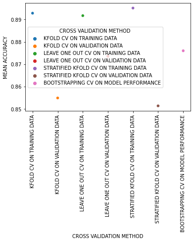

```python
ax = sns.scatterplot(data=MODEL_RESULTS, x="CROSS VALIDATION METHOD", y="MEAN ACCURACY",
                     hue="CROSS VALIDATION METHOD", palette="tab10")

ax.set_xlabel("CROSS VALIDATION METHOD")

ax.set_ylabel("MEAN ACCURACY")

plt.xticks(rotation=90)

plt.show()
```

[output not shown]

# C. Apply hyper-parameter tuning techniques to get the best accuracy.

```
* WE ARE USING ADA BOOST CLASSIFIER AS OUR BASE MODEL AND PROCEED FURTHER ON IMPROVING THE MODEL.

* WE WILL TUNE THE MODEL USING DIFFERENT HYPER PARAMETERS AND CHECK HOW THE MODEL PERFORMS ON THE DATA.

* I AM GOING TO USE GRIDSEARCH CV FOR EACH INDIVIDUAL PARAMETERS AND FIND THE BEST PARAMETER THAT GIVES THE
  BEST ACCURACY.
```

```python
MODEL_TYPE = []
MODEL_TYPE.append(('LOGISTIC REGRESSION', LogisticRegression(solver='lbfgs', max_iter=2000,random_state=1)))
MODEL_TYPE.append(('NAIVE BAYES', GaussianNB()))
MODEL_TYPE.append(('SVM-LINEAR', SVC(kernel='linear')))
MODEL_TYPE.append(('DECISION TREE', DecisionTreeClassifier()))

METRIC_NAME = []
SCORE = []

for name, model in MODEL_TYPE:
    AB = AdaBoostClassifier(base_estimator=model,algorithm='SAMME')
    AB.fit(X_TRAIN, Y_TRAIN)
    Y_PRED = AB.predict(X_VAL)
    acc = accuracy_score(Y_VAL, Y_PRED)
    SCORE.append(acc)
    METRIC_NAME.append(name)

ADB_PARAMETERS = pd.DataFrame(list(zip(METRIC_NAME, SCORE)),
                          columns = ['METRIC_NAME', 'SCORE'])

ADB_PARAMETERS
```

|  | METRIC_NAME | SCORE |
| --- | --- | --- |
| 0 | LOGISTIC REGRESSION | 0.705983 |
| 1 | NAIVE BAYES | 0.690598 |
| 2 | SVM-LINEAR | 0.695726 |
| 3 | DECISION TREE | 0.880342 |

```
* WITH DECISION TREE ALGORITHM, ADA BOOST MODEL HAS BEST ACCURACY OF 88%

* MOVING FORWARD, WE WILL FURTHER TUNE THE OTHER PARAMETERS AND FIND OUT THE BEST PERFORMING PARAMETERS OVERALL.
```

```python
# DEFINE ADA BOOST CLASSIFIER WITH DECISION TREE ALGORITHM

DTC_ALG = DecisionTreeClassifier()

TRAINING_METRIC = []
TRAINING_SCORE = []

VALIDATION_METRIC = []
VALIDATION_SCORE = []

ABC_TUNING = AdaBoostClassifier(base_estimator=DTC_ALG,algorithm='SAMME')

N_ESTIMATORS = {'n_estimators' : np.arange(50,1201,50)}

GRID_ADA = GridSearchCV(estimator = ABC_TUNING, param_grid = N_ESTIMATORS,
                        scoring='accuracy', n_jobs=-1, cv=2, verbose = 1)

GRID_ADA.fit(X_TRAIN,Y_TRAIN)

TRAINING_METRIC.append(GRID_ADA.best_params_)
TRAINING_SCORE.append(round(GRID_ADA.best_score_,2))

print('\nTRAINING DATA METRICS:\nMETRIC NAME:',GRID_ADA.best_params_)

print('\nBEST SCORE:',round(GRID_ADA.best_score_,2))

GRID_ADA.fit(X_VAL,Y_VAL)

VALIDATION_METRIC.append(GRID_ADA.best_params_)
VALIDATION_SCORE.append(round(GRID_ADA.best_score_,2))

print('\n\nVALIDATION DATA METRICS:\nMETRIC NAME:',GRID_ADA.best_params_)

print('\nBEST SCORE:',round(GRID_ADA.best_score_,2))
```

```
Fitting 2 folds for each of 24 candidates, totalling 48 fits

TRAINING DATA METRICS:
METRIC NAME: {'n_estimators': 250}

BEST SCORE: 0.83
Fitting 2 folds for each of 24 candidates, totalling 48 fits


VALIDATION DATA METRICS:
METRIC NAME: {'n_estimators': 1150}

BEST SCORE: 0.75
```

```python
#USE THE N_ESTIMATORS FROM THE ABOVE AND TUNE THE LEARNING RATE:

LEARNING_RATE = {'learning_rate' : np.arange(0.1,1.1,1),'n_estimators' : np.arange(850,901,50)}

GRID_ADA = GridSearchCV(estimator = ABC_TUNING, param_grid = LEARNING_RATE,
                        scoring='accuracy', n_jobs=-1, cv=5, verbose = 1)

GRID_ADA.fit(X_TRAIN,Y_TRAIN)

TRAINING_METRIC.append(GRID_ADA.best_params_)
TRAINING_SCORE.append(round(GRID_ADA.best_score_,2))

print('\nTRAINING DATA METRICS:\nMETRIC NAME:',GRID_ADA.best_params_)

print('\nBEST SCORE:',round(GRID_ADA.best_score_,2))

GRID_ADA.fit(X_VAL,Y_VAL)

VALIDATION_METRIC.append(GRID_ADA.best_params_)
VALIDATION_SCORE.append(round(GRID_ADA.best_score_,2))

print('\n\nVALIDATION DATA METRICS:\nMETRIC NAME:',GRID_ADA.best_params_)

print('\nBEST SCORE:',round(GRID_ADA.best_score_,2))
```

```
Fitting 5 folds for each of 2 candidates, totalling 10 fits

TRAINING DATA METRICS:
METRIC NAME: {'learning_rate': 0.1, 'n_estimators': 850}

BEST SCORE: 0.88
Fitting 5 folds for each of 2 candidates, totalling 10 fits


VALIDATION DATA METRICS:
METRIC NAME: {'learning_rate': 0.1, 'n_estimators': 900}

BEST SCORE: 0.74
```

```python
# LET US TUNE USING THE BASE ESTIMATOR DECISION TREE FOR MAX DEPTH AND EVALUATE THE PERFORMANCE

KF_MODEL_RESULTS = []
MODEL_NAME = "ADA BOOST CLASSIFIER"
scoring = 'accuracy'

for i in np.arange(1,21,1):
    BASE_ESTIMATOR = DecisionTreeClassifier(max_depth = i)
    ADA_BASE = AdaBoostClassifier(base_estimator = BASE_ESTIMATOR,n_estimators = 900,
                                  learning_rate = 0.1, algorithm='SAMME')
    KFOLD = model_selection.KFold(n_splits = 5, shuffle=True, random_state = 65)
    CV_RESULTS = cross_val_score(ADA_BASE, X_TRAIN, Y_TRAIN, cv = KFOLD, scoring=scoring,n_jobs = -1)
    KF_MODEL_RESULTS.append(CV_RESULTS)

print(KF_MODEL_RESULTS)
```

[output not shown]

```python
DECISION_TREE = []
CLASSIFIER = []

for i in np.arange(1,21,1):
    BASE_ESTIMATOR = DecisionTreeClassifier(max_depth = i)
    DECISION_TREE.append(("DECISION TREE"+str(i)))
    CLASSIFIER.append(DecisionTreeClassifier(max_depth = i))

EST_MODELS = pd.DataFrame(list(zip(DECISION_TREE,CLASSIFIER)),columns = ['DECISION_TREE','CLASSIFIER'])
```

```python
SCORE = []
NAME = []

for i in np.arange(0,20,1):
    ADA_BASE = AdaBoostClassifier(base_estimator = CLASSIFIER[i],n_estimators = 900,
                                  learning_rate = 0.1, algorithm='SAMME')
    ADA_BASE.fit(X_TRAIN,Y_TRAIN)
    Y_PRED = ADA_BASE.predict(X_VAL)
    acc = accuracy_score(Y_VAL, Y_PRED)
    SCORE.append(acc)
    NAME.append(DECISION_TREE[i])

CLASSIFIER_DT = pd.DataFrame(list(zip(NAME, SCORE)),
                          columns = ['NAME', 'SCORE'])
```

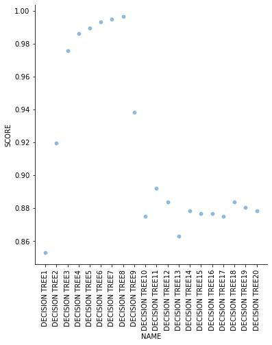

```python
fig = plt.figure(figsize = (10,7))
fig.suptitle('ALGORITHM COMPARISON')
sns.relplot(x = CLASSIFIER_DT.NAME, y = CLASSIFIER_DT.SCORE, sizes=(40, 400), alpha=.5, palette="muted",height=6)
plt.xticks(rotation=90)
plt.show()
```

```python
print(CLASSIFIER_DT[CLASSIFIER_DT.SCORE > 0.90].sort_values(by=['SCORE'], ascending=False))
```

```
             NAME     SCORE
7  DECISION TREE8  0.996581
6  DECISION TREE7  0.994872
5  DECISION TREE6  0.993162
4  DECISION TREE5  0.989744
3  DECISION TREE4  0.986325
2  DECISION TREE3  0.976068
8  DECISION TREE9  0.938462
1  DECISION TREE2  0.919658
```

```
* AFTER TUNING PARAMETERS, WE HAVE AGAIN TUNED DECISION TREE BY INCREASING THE DEPTH OF THE TREE
* FROM MAX DEPTH AT 2 - 9 WE COULD SEE THAT OUR MODEL IS PERFORMING AT AN ACCURACY OF MORE THAN 90%
* AT MAX DEPTH 7 AND 8 WE CAN SEE THAT ACCURACY ALMOST BECAME 100%
* INCREASING THE MAX_DEPTH FROM 2 TO 3 HAS INCREASED ACCURACY BY ALMOST 6%
* AT MAX DEPTH = 9, MODEL ACCURACY AGAIN DECREASED.
* I AM GOING TO TAKE MAX_DEPTH = 4 TO BUILD MY FINAL ADA BOOST MODEL.
```

```python
# BUILD FINAL ADA BOOST CLASSIFIER MODEL AND PRINT THE RESULTS:

RESULTS_FINAL = pd.DataFrame()

MODEL_NAME = "ADA BOOST CLASSIFIER"

DTC_FINAL = DecisionTreeClassifier(max_depth = 4)

ADA_FINAL = AdaBoostClassifier(base_estimator = DTC_FINAL,n_estimators = 900, learning_rate = 0.1, algorithm='SAMME')

ADA_FINAL.fit(X_TRAIN,Y_TRAIN)

Y_PRED = ADA_FINAL.predict(X_VAL)

ACCURACY = accuracy_score(Y_VAL, Y_PRED)

PRECISION = precision_score(Y_VAL, Y_PRED)

RECALL = recall_score(Y_VAL, Y_PRED)

F1_SCORE = f1_score(Y_VAL, Y_PRED)

RESULTS_FINAL = RESULTS_FINAL.append(pd.Series([MODEL_NAME,ACCURACY,PRECISION,RECALL,F1_SCORE]),ignore_index=True)

RESULTS_FINAL.columns = ['MODEL_NAME','ACCURACY','PRECISION','RECALL','F1-SCORE']
```

```python
print('MODEL PERFORMANCE USING TRAINING AND VALIDATION DATA:\n',RESULTS_FINAL)
```

```
MODEL PERFORMANCE USING TRAINING AND VALIDATION DATA:
              MODEL_NAME  ACCURACY  PRECISION    RECALL  F1-SCORE
0  ADA BOOST CLASSIFIER  0.984615   0.970909  0.996269  0.983425
```

```python
print(classification_report(Y_VAL,Y_PRED),'\n')
```

```
              precision    recall  f1-score   support

          -1       1.00      0.97      0.99       317
           1       0.97      1.00      0.98       268

    accuracy                           0.98       585
   macro avg       0.98      0.99      0.98       585
weighted avg       0.98      0.98      0.98       585
```

[output not shown]

# D. Use any other technique/method which can enhance the model performance.

[output not shown]

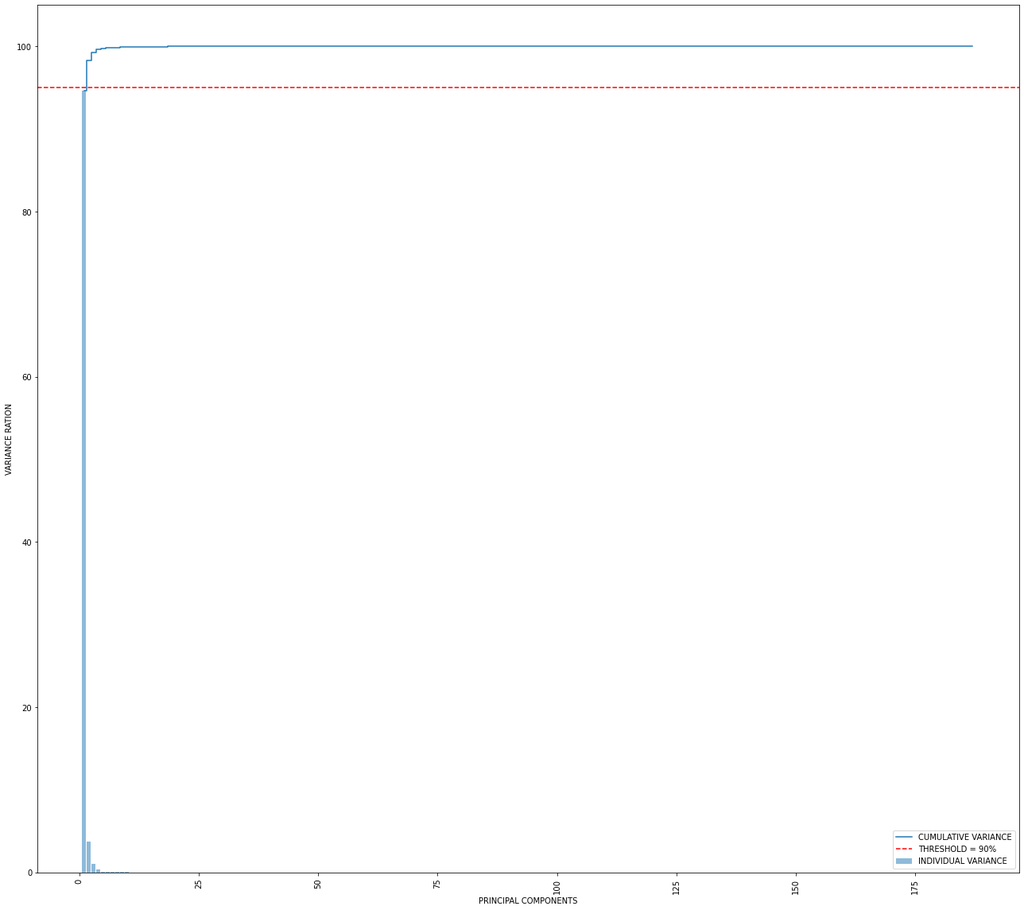

```python
PCA_MODEL = PCA()

PCA_DATA = PCA_MODEL.fit_transform(X_TRAIN)
COV_MX = np.cov(X_TRAIN.T)

EIGEN_VALUES, EIGEN_VECTORS = np.linalg.eig(COV_MX)

TOTAL = sum(EIGEN_VALUES)
VAR = [( i /TOTAL ) * 100 for i in sorted(EIGEN_VALUES, reverse=True)]
C_VAR = np.cumsum(VAR)

plt.figure(figsize=(18 , 16))
plt.bar(range(1, EIGEN_VALUES.size + 1), VAR, alpha = 0.5, align = 'center', label = 'INDIVIDUAL VARIANCE')
plt.step(range(1, EIGEN_VALUES.size + 1), C_VAR, where='mid', label = 'CUMULATIVE VARIANCE')
plt.axhline(y = 95, color = 'r', linestyle = 'dashed', label = "THRESHOLD = 90%")
plt.ylabel('VARIANCE RATION')
plt.xlabel('PRINCIPAL COMPONENTS')
plt.xticks(rotation=90)
plt.legend(loc = 'best')
plt.tight_layout()
plt.show()
```

[output not shown]

```python
PCA_RESULTS = pd.DataFrame()

ADA_PCA = AdaBoostClassifier(base_estimator = DTC_FINAL,n_estimators = 900, learning_rate = 0.1, algorithm='SAMME')

for i in np.arange(1,188,6):
    PCA_MODEL = PCA(n_components=i)
    X_TRAIN_PCA = PCA_MODEL.fit_transform(X_TRAIN)
    X_VAL_PCA = PCA_MODEL.fit_transform(X_VAL)
    ADA_PCA.fit(X_TRAIN_PCA, Y_TRAIN)
    PREDICTION = ADA_PCA.predict(X_VAL_PCA)
    ACCURACY = accuracy_score(Y_VAL, PREDICTION)
    PCA_RESULTS = PCA_RESULTS.append(pd.Series([i,ACCURACY]),ignore_index=True)

PCA_RESULTS.columns = ['NO OF COMPONENTS', 'ACCURACY']
```

```python
print(PCA_RESULTS.sort_values('ACCURACY',ascending = False))
```

```
    NO OF COMPONENTS  ACCURACY
29             175.0  0.888889
31             187.0  0.887179
30             181.0  0.885470
28             169.0  0.876923
25             151.0  0.868376
23             139.0  0.868376
22             133.0  0.868376
26             157.0  0.863248
24             145.0  0.859829
27             163.0  0.858120
21             127.0  0.844444
20             121.0  0.825641
13              79.0  0.818803
18             109.0  0.811966
```

[output cut: 18 more lines]

```
* ON APPLYING PCA ON THE DATA, WE CAN SEE THAT MODEL ACCURACY IS ACTUALLY REDUCED TO 88% AGAINST THE 98%
  IN THE HYPER TUNING OF THE BASE MODEL.

* WE WILL NOTMALISE THE DATA USING ZSCORE METHOD AND RUN THE ADA BOOST MODEL AGAIN.
```

```python
RESULTS = pd.DataFrame()

X_TRAIN_Z = X_TRAIN.apply(zscore)
X_VAL_Z = X_VAL.apply(zscore)

ADA_PCA = AdaBoostClassifier(base_estimator = DTC_FINAL,n_estimators = 900, learning_rate = 0.1, algorithm='SAMME')

ADA_PCA.fit(X_TRAIN_Z, Y_TRAIN)
PREDICTION = ADA_PCA.predict(X_VAL_Z)
ACCURACY = accuracy_score(Y_VAL, PREDICTION)
RESULTS = RESULTS.append(pd.Series(["ADA_NORMALIZED",ACCURACY]),ignore_index=True)
```

```python
RESULTS.columns = ['MODEL TYPE', 'ACCURACY']

print("PCA MODEL RESULTS ON NORMALIZED DATA:\n",RESULTS)
```

```
PCA MODEL RESULTS ON NORMALIZED DATA:
        MODEL TYPE  ACCURACY
0  ADA_NORMALIZED  0.892308
```

```
* ON NORMALIZING THE DATA WE HAVE MODEL ACCURACY OF 89.23% WHICH IS MUCH LESSER THAN THE MODEL WE TRAINED
  USING HYPERPARAMETER TUNING.
```

```python
print(classification_report(Y_VAL,PREDICTION),'\n')
```

```
              precision    recall  f1-score   support

          -1       1.00      0.80      0.89       317
           1       0.81      1.00      0.89       268

    accuracy                           0.89       585
   macro avg       0.90      0.90      0.89       585
weighted avg       0.91      0.89      0.89       585
```

# E. Display and explain the classification report in detail.

```python
# BUILD FINAL ADA BOOST CLASSIFIER MODEL AND PRINT THE RESULTS:

RESULTS_FINAL = pd.DataFrame()

MODEL_NAME = "ADA BOOST CLASSIFIER"

DTC_FINAL = DecisionTreeClassifier(max_depth = 4)

ADA_FINAL = AdaBoostClassifier(base_estimator = DTC_FINAL,n_estimators = 900, learning_rate = 0.1, algorithm='SAMME')

ADA_FINAL.fit(X_TRAIN,Y_TRAIN)

Y_PRED = ADA_FINAL.predict(X_VAL)

ACCURACY = accuracy_score(Y_VAL, Y_PRED)

PRECISION = precision_score(Y_VAL, Y_PRED)

RECALL = recall_score(Y_VAL, Y_PRED)

F1_SCORE = f1_score(Y_VAL, Y_PRED)

RESULTS_FINAL = RESULTS_FINAL.append(pd.Series([MODEL_NAME,ACCURACY,PRECISION,RECALL,F1_SCORE]),ignore_index=True)

RESULTS_FINAL.columns = ['MODEL_NAME','ACCURACY','PRECISION','RECALL','F1-SCORE']

print('MODEL PERFORMANCE USING TRAINING AND VALIDATION DATA:\n',RESULTS_FINAL)
```

```
MODEL PERFORMANCE USING TRAINING AND VALIDATION DATA:
              MODEL_NAME  ACCURACY  PRECISION    RECALL  F1-SCORE
0  ADA BOOST CLASSIFIER  0.984615   0.970909  0.996269  0.983425
```

```python
print(classification_report(Y_VAL,Y_PRED),'\n')
```

```
              precision    recall  f1-score   support

          -1       1.00      0.97      0.99       317
           1       0.97      1.00      0.98       268

    accuracy                           0.98       585
   macro avg       0.98      0.99      0.98       585
weighted avg       0.98      0.98      0.98       585
```

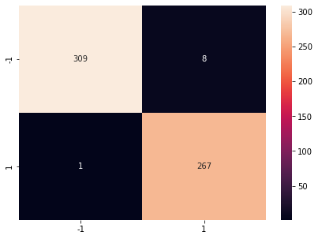

```python
CM = metrics.confusion_matrix(Y_VAL, Y_PRED,labels=[-1, 1])

CM_DF = pd.DataFrame(CM, index = [i for i in ["-1","1"]],
                  columns = [i for i in ["-1","1"]])

plt.figure(figsize = (7,5))

sns.heatmap(CM_DF, annot=True ,fmt='g')
```

[output not shown]

```python
# BUILD FINAL ADA BOOST CLASSIFIER MODEL AND PRINT THE RESULTS USING TESTING DATA:

RESULTS_FINAL = pd.DataFrame()

MODEL_NAME = "ADA BOOST CLASSIFIER"

DTC_FINAL = DecisionTreeClassifier(max_depth = 4)

ADA_FINAL = AdaBoostClassifier(base_estimator = DTC_FINAL,n_estimators = 900, learning_rate = 0.1, algorithm='SAMME')

ADA_FINAL.fit(X_TRAIN,Y_TRAIN)

Y_PRED = ADA_FINAL.predict(X_TEST)

ACCURACY = accuracy_score(Y_TEST, Y_PRED)

PRECISION = precision_score(Y_TEST, Y_PRED)

RECALL = recall_score(Y_TEST, Y_PRED)

F1_SCORE = f1_score(Y_TEST, Y_PRED)

RESULTS_FINAL = RESULTS_FINAL.append(pd.Series([MODEL_NAME,ACCURACY,PRECISION,RECALL,F1_SCORE]),ignore_index=True)

RESULTS_FINAL.columns = ['MODEL_NAME','ACCURACY','PRECISION','RECALL','F1-SCORE']

print('MODEL PERFORMANCE USING TRAINING AND TEST DATA:\n',RESULTS_FINAL)
```

```
MODEL PERFORMANCE USING TRAINING AND TEST DATA:
              MODEL_NAME  ACCURACY  PRECISION    RECALL  F1-SCORE
0  ADA BOOST CLASSIFIER  0.991468   0.992806  0.989247  0.991023
```

```
              precision    recall  f1-score   support

          -1       0.99      0.99      0.99       307
           1       0.99      0.99      0.99       279

    accuracy                           0.99       586
   macro avg       0.99      0.99      0.99       586
weighted avg       0.99      0.99      0.99       586
```

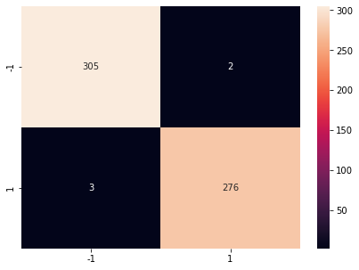

```python
print(classification_report(Y_TEST,Y_PRED),'\n\n\n')

CM = metrics.confusion_matrix(Y_TEST, Y_PRED,labels=[-1, 1])

CM_DF = pd.DataFrame(CM, index = [i for i in ["-1","1"]],
                  columns = [i for i in ["-1","1"]])

plt.figure(figsize = (7,5))

sns.heatmap(CM_DF, annot=True ,fmt='g')
```

[output not shown]

# F. Apply the above steps for all possible models that you have learnt so far.

```
1. BUILD A BASE MODEL USING VARIOUS MACHINE LEARNING ALGORITHMS AND FIND THE ACCURACY.
```

```python
def MODEL(MODEL_TYPE,X_TRAIN, Y_TRAIN, X_VAL, Y_VAL):
    RESULTS = pd.DataFrame()
    for name, model in MODEL_TYPE:
        MODEL_EVAL = model
        MODEL_EVAL.fit(X_TRAIN, Y_TRAIN)
        Y_PRED = MODEL_EVAL.predict(X_VAL)
        ACCURACY = accuracy_score(Y_VAL, Y_PRED)
        PRECISION = precision_score(Y_VAL, Y_PRED)
        RECALL = recall_score(Y_VAL, Y_PRED)
        F1_SCORE = f1_score(Y_VAL, Y_PRED)
        RESULTS = RESULTS.append(pd.Series([name,ACCURACY,PRECISION,RECALL,F1_SCORE]),ignore_index=True)
    RESULTS.columns = ['MODEL_NAME','ACCURACY','PRECISION','RECALL','F1-SCORE']
    return RESULTS
```

```python
MODEL_TYPE = []
MODEL_TYPE.append(('LOGISTIC REGRESSION', LogisticRegression(solver='lbfgs', max_iter=2000,random_state=1)))
MODEL_TYPE.append(('KNN CLASSIFIER', KNeighborsClassifier(n_neighbors=10)))
MODEL_TYPE.append(('NAIVE BAYES', GaussianNB()))
MODEL_TYPE.append(('RANDOM FOREST', RandomForestClassifier()))
MODEL_TYPE.append(('DECISION TREE', DecisionTreeClassifier()))
MODEL_TYPE.append(('XGB CLASSIFIER', XGBClassifier(eval_metric = ["auc","error"])))
MODEL_TYPE.append(('GRADIENT BOOST', GradientBoostingClassifier()))
```

```python
RESULTS = MODEL(MODEL_TYPE,X_TRAIN, Y_TRAIN, X_VAL, Y_VAL)
print('\nRESULTS USING VARIOUS MACHINE LEARNING ALGORITHMS:\n')
print('*******************************************************************\n',RESULTS)
```

[output not shown]

```
2. USING KFOLD TECHNIQUE TO EVALUATE THE MODELS PERFORMANCE
```

```python
def CV_BESTMODEL(MODEL_TYPES,X_TRAIN,Y_TRAIN):
    MODEL_RESULTS = []
    MODEL_NAME = []
    scoring = 'accuracy'
    for name, model in MODEL_TYPES:
        KFOLD = model_selection.KFold(n_splits=10, random_state=7,shuffle=True)
        CV_RESULTS = model_selection.cross_val_score(model,  X_TRAIN,Y_TRAIN, cv = KFOLD, scoring=scoring)
        MODEL_RESULTS.append(CV_RESULTS)
        MODEL_NAME.append(name)
        msg = "%s: %f (%f)" % (name, CV_RESULTS.mean(), CV_RESULTS.std())
        print(msg)

    fig = plt.figure(figsize = (20,10))
    fig.suptitle('ALGORITHM COMPARISON')
    ax = fig.add_subplot(111)
    plt.boxplot(MODEL_RESULTS)
    ax.set_xticklabels(MODEL_NAME)
    plt.show()
```

[output not shown]

[figure not shown]

```python
CV_BESTMODEL(MODEL_TYPE,X_TRAIN,Y_TRAIN)
```

```
3. USE STRATIFED KFOLD TECHNIQUE AND EVALUATE THE MODELS PERFORMANCE.
```

```python
def KFCV_BESTMODEL(MODEL_TYPES,X_TRAIN,Y_TRAIN):
    MODEL_RESULTS = []
    MODEL_NAME = []
    scoring = 'accuracy'
    for name, model in MODEL_TYPES:
        KFOLD = StratifiedKFold(n_splits = 5, shuffle=True, random_state = 65)
        KFCV_RESULTS = model_selection.cross_val_score(model,  X_TRAIN,Y_TRAIN, cv = KFOLD, scoring=scoring)
        MODEL_RESULTS.append(KFCV_RESULTS)
        MODEL_NAME.append(name)
        msg = "%s: %f (%f)" % (name, KFCV_RESULTS.mean(), KFCV_RESULTS.std())
        print(msg)

    fig = plt.figure(figsize = (20,10))
    fig.suptitle('ALGORITHM COMPARISON')
    ax = fig.add_subplot(111)
    plt.boxplot(MODEL_RESULTS)
    ax.set_xticklabels(MODEL_NAME)
    plt.show()
```

[output not shown]

[figure not shown]

```python
KFCV_BESTMODEL(MODEL_TYPE,X_TRAIN,Y_TRAIN)
```

```
4. USE REPEATED STRATIFIED KFOLD AND EVALUATE THE MODELS PERFORMANCE.
```

```python
def RSKFCV_BESTMODEL(MODEL_TYPES,X_TRAIN,Y_TRAIN):
    MODEL_RESULTS = []
    MODEL_NAME = []
    scoring = 'accuracy'
    for name, model in MODEL_TYPES:
        RSKFOLD = RepeatedStratifiedKFold(n_splits=3, n_repeats=3, random_state=65)
        RSKFCV_RESULTS = model_selection.cross_val_score(model,  X_TRAIN,Y_TRAIN, cv = RSKFOLD, scoring=scoring)
        MODEL_RESULTS.append(RSKFCV_RESULTS)
        MODEL_NAME.append(name)
        msg = "%s: %f (%f)" % (name, RSKFCV_RESULTS.mean(), RSKFCV_RESULTS.std())
        print(msg)

    fig = plt.figure(figsize = (20,10))
    fig.suptitle('ALGORITHM COMPARISON')
    ax = fig.add_subplot(111)
    plt.boxplot(MODEL_RESULTS)
    ax.set_xticklabels(MODEL_NAME)
    plt.show()
```

[output not shown]

[figure not shown]

```python
RSKFCV_BESTMODEL(MODEL_TYPE,X_TRAIN,Y_TRAIN)
```

```
4. USE RANDOMIZED SEARCH CV TO FIND THE HYPERPARAMETERS.

    NOTE: RANDOMIZED SEARCH METHOD PROVIDES A COMBINATION OF PARAMETERS THAT HAS BEST PERFORMANCE USING MODEL
          THESE PARAMETERS COMBINATION CHANGES AT EVERY RUN OF THE ML MODEL.
```

```python
def BEST_MODEL_PARAMS(MODELS,X_TRAIN,Y_TRAIN):
    BEST_SCORE = []
    MODELAME = []
    for name, model, params in MODELS:
        SEARCH_BEST = RandomizedSearchCV(model, n_iter=10, scoring='accuracy',
                                         param_distributions = params, n_jobs=-1, cv=3, random_state=1)
        TUNE_RESULTS = SEARCH_BEST.fit(X_TRAIN, Y_TRAIN)
        print(name)
        print('*******************************************************************************************')
        print('BEST SCORE: %s' % TUNE_RESULTS.best_score_)
        print('BEST PARAMETERS: %s' % TUNE_RESULTS.best_params_)
        print('\n\n')
        MODELAME.append(name)
        BEST_SCORE.append(TUNE_RESULTS.best_score_)
    return MODELAME, BEST_SCORE
```

```python
MODEL_BEST = []

MODEL_BEST.append(('LOGISTIC REGRESSION', LogisticRegression(),{'solver' : ['newton-cg', 'lbfgs', 'liblinear'],
                                                                'penalty' : ['none', 'l1', 'l2', 'elasticnet'],
                                                                'C' : np.arange(0.1,1.1,.1)}))

MODEL_BEST.append(('KNN CLASSIFIER', KNeighborsClassifier(),{'n_neighbors' : np.arange(5,51,2),
                                                             'weights' : ['uniform','distance'],
                                                             'metric' : ['minkowski','euclidean',
                                                                         'manhattan','chebyshev']}))

MODEL_BEST.append(('NAIVE BAYES', GaussianNB(),{'var_smoothing': np.logspace(0,-9, num=100)}))
```

```python
BEST_MODEL_PARAMS(MODEL_BEST,X_TRAIN,Y_TRAIN)
```

```
LOGISTIC REGRESSION
BEST SCORE: 0.8284900284900285
BEST PARAMETERS: {'solver': 'newton-cg', 'penalty': 'none', 'C': 0.5}



KNN CLASSIFIER
BEST SCORE: 0.7846153846153846
BEST PARAMETERS: {'weights': 'distance', 'n_neighbors': 5, 'metric': 'euclidean'}



NAIVE BAYES
BEST SCORE: 0.7287749287749287
BEST PARAMETERS: {'var_smoothing': 3.5111917342151273e-09}
```

```
(['LOGISTIC REGRESSION', 'KNN CLASSIFIER', 'NAIVE BAYES'],
 [0.8284900284900285, 0.7846153846153846, 0.7287749287749287])
```

```python
XGB_BEST = []

XGB_BEST.append(('XGB CLASSIFIER', XGBClassifier(eval_metric = ["auc","error"]),{'learning_rate': np.arange(0.1, 0.4, 0.2),
                                                                                   'n_estimators': np.arange(400, 501, 100),
                                                                                   'max_depth': np.arange(4, 6, 1),
                                                                                   'gamma': np.arange(0.8, 1.0, 0.1),
                                                                                   'min_child_weight': np.arange(4, 7, 2),
                                                                                   'reg_alpha': np.arange(0.5, 0.7, 0.1),
                                                                                   'reg_lambda': np.arange(0.3, 0.5, 0.1),
                                                                                   'subsample': np.arange(0.9, 1.1, 0.1),
                                                                                   'colsample_bytree': np.arange(0.7, 1.0, 0.2)}))
```

```python
BEST_MODEL_PARAMS(XGB_BEST,X_TRAIN,Y_TRAIN)
```

```
XGB CLASSIFIER
BEST SCORE: 0.9584045584045584
BEST PARAMETERS: {'subsample': 0.9, 'reg_lambda': 0.4, 'reg_alpha': 0.6, 'n_estimators': 500, 'min_child_weight': 6, 'max_depth': 5, 'learning_rate': 0.1, 'gamma': 0.9, 'colsample_bytree': 0.7}
```

```
(['XGB CLASSIFIER'], [0.9584045584045584])
```

```python
RF_BEST = []

RF_BEST.append(('RANDOM FOREST', RandomForestClassifier(),{'n_estimators': np.arange(300,501,100),
                                                              'max_features': ['auto','sqrt'],
                                                              'max_depth': np.arange(5, 7, 1),
                                                              'criterion': ['gini','entropy'],
                                                              'bootstrap': [True, False]}))
```

```python
BEST_MODEL_PARAMS(RF_BEST,X_TRAIN,Y_TRAIN)
```

```
RANDOM FOREST
BEST SCORE: 0.9344729344729344
BEST PARAMETERS: {'n_estimators': 400, 'max_features': 'auto', 'max_depth': 6, 'criterion': 'gini', 'bootstrap': False}
```

```
(['RANDOM FOREST'], [0.9344729344729344])
```

```python
DT_BEST = []

DT_BEST.append(('DECISION TREE', DecisionTreeClassifier(),{'max_depth': [2, 3, 5, 10, 20],
                                                              'min_samples_leaf': [5, 10, 20, 50, 100],
                                                              'criterion': ["gini", "entropy"]}))
```

```python
BEST_MODEL_PARAMS(DT_BEST,X_TRAIN,Y_TRAIN)
```

```
DECISION TREE
BEST SCORE: 0.8404558404558404
BEST PARAMETERS: {'min_samples_leaf': 5, 'max_depth': 10, 'criterion': 'entropy'}
```

```
(['DECISION TREE'], [0.8404558404558404])
```

```python
GBC_BEST = []

GBC_BEST.append(('GRADIENT BOOST', GradientBoostingClassifier(),{'n_estimators': np.arange(300,501,100),
                                                              'max_features': ['auto','sqrt','log2'],
                                                              'max_depth': np.arange(5, 7, 1),
                                                              'criterion': ['friedman_mse','squared_error','mse','mae'],
                                                              'loss': ['deviance','exponential']}))
```

```python
BEST_MODEL_PARAMS(GBC_BEST,X_TRAIN,Y_TRAIN)
```

```
GRADIENT BOOST
BEST SCORE: 0.974928774928775
BEST PARAMETERS: {'n_estimators': 300, 'max_features': 'log2', 'max_depth': 6, 'loss': 'exponential', 'criterion': 'friedman_mse'}
```

```
(['GRADIENT BOOST'], [0.974928774928775])
```

# 6. Post Training and Conclusion:

# A. Display and compare all the models designed with their train and test accuracies.

```python
MODELS_TUNED = []
MODELS_TUNED.append(('LOGISTIC REGRESSION_TUNED', LogisticRegression(solver='newton-cg', penalty = 'none', C= 0.5)))
MODELS_TUNED.append(('KNN CLASSIFIER_TUNED', KNeighborsClassifier(weights = 'distance', n_neighbors=5,
                                                                  metric = 'euclidean')))
MODELS_TUNED.append(('NAIVE BAYES_TUNED', GaussianNB(var_smoothing = 0.0000000001)))
MODELS_TUNED.append(('RANDOM FOREST_TUNED', RandomForestClassifier(n_estimators= 400, max_features= 'auto',
                                                                   max_depth= 6, criterion= 'gini', bootstrap= False)))
MODELS_TUNED.append(('DECISION TREE_TUNED', DecisionTreeClassifier(min_samples_leaf= 5,
                                                                   max_depth= 10, criterion= 'entropy')))
MODELS_TUNED.append(('XGB CLASSIFIER_TUNED', XGBClassifier(eval_metric = ["auc","error"],subsample= 0.9,
                                                           reg_lambda= 0.4, reg_alpha= 0.6, n_estimators= 500,
                                                           min_child_weight= 6, max_depth= 5, learning_rate= 0.1,
                                                           gamma= 0.9, colsample_bytree= 0.7)))
MODELS_TUNED.append(('GRADIENT BOOST_TUNED', GradientBoostingClassifier(n_estimators= 300, max_features= 'log2',
                                                                        max_depth= 6, loss= 'exponential',
                                                                        criterion= 'friedman_mse')))
MODELS_TUNED.append(('ADA BOOST_TUNED', AdaBoostClassifier(base_estimator = DecisionTreeClassifier(max_depth = 4),
                                                           n_estimators = 900,learning_rate = 0.1, algorithm='SAMME')))
```

```python
RESULTS = MODEL(MODELS_TUNED,X_TRAIN, Y_TRAIN, X_TEST, Y_TEST)
print('\nRESULTS AFTER HYPER TUNING MODELS:\n')
print('*******************************************************************\n',RESULTS)
```

```
RESULTS AFTER HYPER TUNING MODELS:

                   MODEL_NAME  ACCURACY  PRECISION    RECALL  F1-SCORE
0  LOGISTIC REGRESSION_TUNED  0.853242   0.789790  0.942652  0.859477
1       KNN CLASSIFIER_TUNED  0.786689   0.694444  0.985663  0.814815
2          NAIVE BAYES_TUNED  0.679181   0.610169  0.903226  0.728324
3        RANDOM FOREST_TUNED  0.950512   0.922297  0.978495  0.949565
4        DECISION TREE_TUNED  0.885666   0.858108  0.910394  0.883478
5       XGB CLASSIFIER_TUNED  0.974403   0.974820  0.971326  0.973070
6       GRADIENT BOOST_TUNED  0.989761   0.989247  0.989247  0.989247
7            ADA BOOST_TUNED  0.988055   0.989209  0.985663  0.987433
```

```
* USE KFOLD CROSS VALIDATION TO EVALUATE THE MODELS ON TRAINING DATA.
```

```
LOGISTIC REGRESSION_TUNED: 0.825071 (0.015873)
KNN CLASSIFIER_TUNED: 0.797151 (0.023727)
NAIVE BAYES_TUNED: 0.720228 (0.039780)
RANDOM FOREST_TUNED: 0.937322 (0.013118)
DECISION TREE_TUNED: 0.830199 (0.016768)
XGB CLASSIFIER_TUNED: 0.959544 (0.010721)
GRADIENT BOOST_TUNED: 0.978348 (0.009293)
ADA BOOST_TUNED: 0.973789 (0.005811)
```

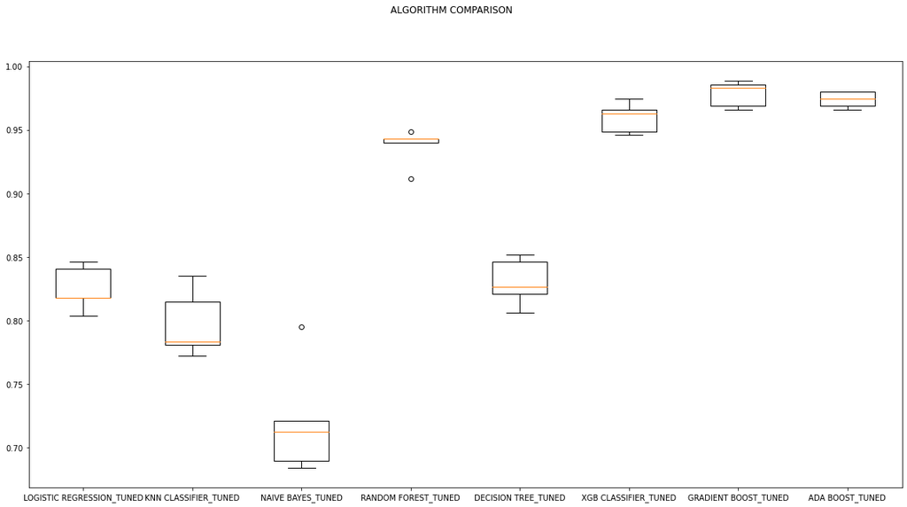

```python
KFCV_BESTMODEL(MODELS_TUNED,X_TRAIN,Y_TRAIN)
```

```
* USE KFOLD CROSS VALIDATION TO EVALUATE THE MODELS ON TESTING DATA.
```

```
LOGISTIC REGRESSION_TUNED: 0.798653 (0.038725)
KNN CLASSIFIER_TUNED: 0.740562 (0.020512)
NAIVE BAYES_TUNED: 0.607475 (0.026372)
RANDOM FOREST_TUNED: 0.923236 (0.016051)
DECISION TREE_TUNED: 0.812415 (0.052594)
XGB CLASSIFIER_TUNED: 0.897668 (0.020559)
GRADIENT BOOST_TUNED: 0.943662 (0.010354)
ADA BOOST_TUNED: 0.926684 (0.020312)
```

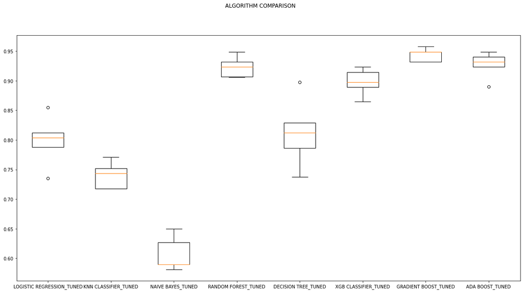

```python
KFCV_BESTMODEL(MODELS_TUNED,X_TEST,Y_TEST)
```

[output not shown]

```
* PRINT THE CLASSIFICATION MATRIX AND CONFUSION MATRIX FOR ALL THE MODELS AFTER HYPERTUNING
```

```python
def CONFUSION_MATRIX(MODEL_TYPE):
    for name, model in MODEL_TYPE:
        MODEL_EVAL = model
        Y_PRED = MODEL_EVAL.predict(X_TEST)

        CM = metrics.confusion_matrix(Y_TEST, Y_PRED,labels=[-1, 1])

        CM_DF = pd.DataFrame(CM, index = [i for i in ["-1","1"]],
                  columns = [i for i in ["-1","1"]])

        plt.figure(figsize = (7,5))

        plt.title(name)

        sns.heatmap(CM_DF, annot=True ,fmt='g')

        plt.show()
```

```python
def CLASSIFICATION_REPORT(MODEL_TYPE):
    RESULTS = pd.DataFrame()
    for name, model in MODEL_TYPE:
        MODEL_EVAL = model
        MODEL_EVAL.fit(X_TRAIN, Y_TRAIN)
        Y_PRED = MODEL_EVAL.predict(X_TEST)
        print('CLASSIFICATION REPORT FOR ',name)
        print('******************************************************************')
        print(classification_report(Y_TEST,Y_PRED),'\n')
```

```python
CLASSIFICATION_REPORT(MODELS_TUNED)
```

```
CLASSIFICATION REPORT FOR  LOGISTIC REGRESSION_TUNED
              precision    recall  f1-score   support

          -1       0.94      0.77      0.85       307
           1       0.79      0.94      0.86       279

    accuracy                           0.85       586
   macro avg       0.86      0.86      0.85       586
weighted avg       0.87      0.85      0.85       586


CLASSIFICATION REPORT FOR  KNN CLASSIFIER_TUNED
              precision    recall  f1-score   support

          -1       0.98      0.61      0.75       307
           1       0.69      0.99      0.81       279

    accuracy                           0.79       586
   macro avg       0.84      0.80      0.78       586
weighted avg       0.84      0.79      0.78       586


CLASSIFICATION REPORT FOR  NAIVE BAYES_TUNED
              precision    recall  f1-score   support

          -1       0.84      0.48      0.61       307
           1       0.61      0.90      0.73       279

    accuracy                           0.68       586
   macro avg       0.73      0.69      0.67       586
weighted avg       0.73      0.68      0.67       586


CLASSIFICATION REPORT FOR  RANDOM FOREST_TUNED
              precision    recall  f1-score   support

          -1       0.98      0.92      0.95       307
           1       0.92      0.98      0.95       279

    accuracy                           0.95       586
```

[output cut: 31 more lines]

```

    accuracy                           0.99       586
   macro avg       0.99      0.99      0.99       586
weighted avg       0.99      0.99      0.99       586


CLASSIFICATION REPORT FOR  ADA BOOST_TUNED
              precision    recall  f1-score   support

          -1       0.99      0.99      0.99       307
           1       0.99      0.99      0.99       279

    accuracy                           0.99       586
   macro avg       0.99      0.99      0.99       586
weighted avg       0.99      0.99      0.99       586
```

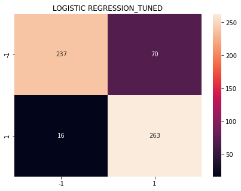

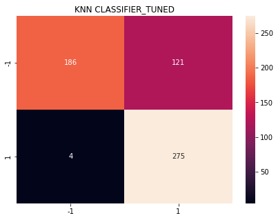

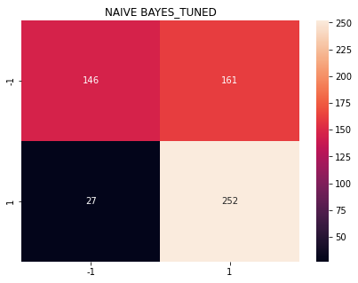

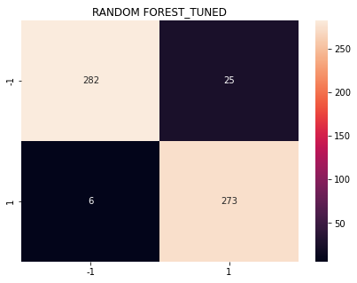

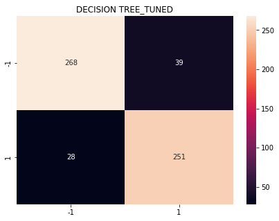

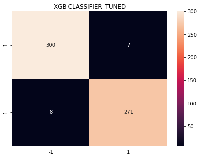

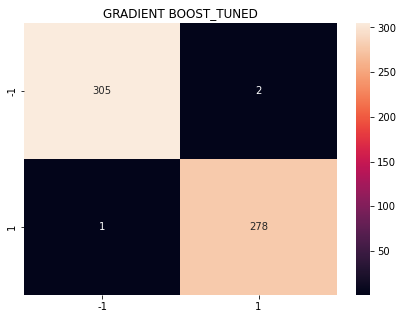

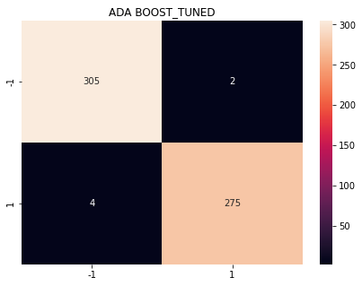

```python
CONFUSION_MATRIX(MODELS_TUNED)
```

[output not shown]

# B. Select the final best trained model along with your detailed comments for selecting this model.

[output not shown]

# C. Pickle the selected model for future use.

```python
# IMPORT PICKLE MODULE

import pickle
```

```python
# PICK THE FINAL MODEL I HAVE SELECTED, IN THIS ASSESSMENT, ADA BOOSTING CLASSIFIER WITH DECISION TREE

# SAVE THE MODEL INTO NEW NAME ADA_BOOST_MODEL

# PICKLE THE MODEL INTO NEW FILE ABC_PICKLE

ADA_BOOST_MODEL = AdaBoostClassifier(base_estimator = DecisionTreeClassifier(max_depth = 4),
                                     n_estimators = 900, learning_rate = 0.1, algorithm='SAMME')

ABC_PICKLE = 'ADA_BOOST_MODEL.sav'
pickle.dump(ADA_BOOST_MODEL, open(ABC_PICKLE, 'wb'))
```

```python
# LOAD THE PICKLED MODEL INTO A NEW VARIABLE LOAD_MODEL

LOAD_MODEL = pickle.load(open(ABC_PICKLE, 'rb'))
```

```python
# RUN THE LOADED PICKLED MODEL AND PRINTING THE RESULTS.

PICKLE_RESULTS = pd.DataFrame()

LOAD_MODEL.fit(X_TRAIN, Y_TRAIN)
Y_PRED = LOAD_MODEL.predict(X_TEST)
ACCURACY = accuracy_score(Y_TEST, Y_PRED)
PRECISION = precision_score(Y_TEST, Y_PRED)
RECALL = recall_score(Y_TEST, Y_PRED)
F1_SCORE = f1_score(Y_TEST, Y_PRED)
PICKLE_RESULTS = PICKLE_RESULTS.append(pd.Series([ACCURACY,PRECISION,RECALL,F1_SCORE]),ignore_index=True)
PICKLE_RESULTS.columns = ['ACCURACY','PRECISION','RECALL','F1-SCORE']
print(PICKLE_RESULTS)
```

```
   ACCURACY  PRECISION    RECALL  F1-SCORE
0  0.989761    0.99278  0.985663  0.989209
```

```
# I IMORTED THE PICKLE MODULE AND THE SAVED THE FINAL ADA BOOST MODEL INTO ABC_PICKLE.

# IN THE JUPYTER NOTE BOOK, THERE IS AN INSTANCE OF PICKLE NAMED ADA_BOOST_MODEL.sav

# THIS FILE CAN BE IMORTED INTO ANY MODEL RATHER THAN WRITING THE WHOLE CODE.

# I HAVE LOADED THE PICKLED MODEL AGAIN INTO LOAD_MODEL VARIABLE

# LATER I RAN THE PICKLED MODEL AND PRINTED THE RESULTS FOR THE REFERENCE.

# WITH THIS I CONLUDE THAT PICKLE MODEL IS WORKING WIHT OUT ISSUES.
```

# D. Write your conclusion on the results.

```
1. I HAVE SPLIT THE DATA INTO TRAIN, VALIDATION AND TEST SETS.

2. BY DOING THIS, WE CAN KEEP THE TEST DATA AWAY FROM GETTING EXPOSED TO TAINING MODEL AMD ADJUSTING ITSELF TO
   THE TEST DATA AND RESULTS GETTING ADJUSTED

3. BEFORE TUNING THE PARAMETERS, WE HAVE MODEL PERFORMED AT 90% ACCURACY WHICH IS VERY GOOD.

4. I HAVE RAN CROSS VALIDATION TECHNIQUES LIKE KVFOLD, STRATIFIED KVFOLD, LEAVE ONE OUT AND BOOT STRAPPING.

4. I GAVE COMPARED THE MEAN ACCURACY AND STANDARD DEVIATIONS USING ALL THE VALIDATION TECHNIQUES.

5. STRATIFIED KFOLD HAS GOOD MEAN ACCURACY BUT LEAVE ONE OUT HAS LEAST STANDARD DEVIATION.

6. I HAVE SELECTED DECISION TREE AS BASE ESTIMATOR AND THEN CHECKED FOR USING VARIOUS MAX DEPTH VALUES.

7. I HAVE SELECTED MAX_DEPTH = 4 AND PROCEEDED FOR HYPERTUNING THE PARAMETERS.

8. REASON FOR SELECTING THE ADA BOOST IS IT HAS LESS PARAMETERS FOR TUNING AND TUNING BASE ESTIMATOR HELPS
   IN IMPROVING THE OVERALL ACCURACY.

9. ADA BOOST IS LESS PRONE TO OVERFITTING THE DATA AND MODE ADAPTABLE TO DATA SETS ON TRAINING.

10. MODEL HAS PROVIDED BETTER RESULTS OVER BASE MODEL AFTER TUNING USING VALIDATION DATA SET.

11. EVEN KEEPING THE TEST SET AWAY FROM THE MODEL TRAINING, WE CAN SEE THE MODEL IS STILL PERFORMING
    EXCEPTIONALLY WELL WITH AN ACCURACY OF NEARLY 99% WHICH IS ALMOST REACHING TO 100%

12. I HAVE USED LASSO REGRESSION METHOD AND DROPPED CERTAIN VARIABLES WHICH HAVE COEFFICIENT 0.

13. I USED VARIANCE INFLATION FACTOR TO DEAL WITH MULTI COLLINEARITY AND DROPPED SOME OF THE FEATURES.
```

```
        *************************** END OF FMT PROBLEM STATEMENT SOLUTION ***************************
```